# Introduction to R

László Kovács

08/02/2025

## 1. What is R?

R is a programming language that has a specific purpose: to execute statistical calculations and data visualization. R has remarkable capabilities compared to other programming languages in the following areas:

- Matrix operations and handling multidimensional arrays
- Data visualization tools
- External libraries that implement the latest statistical and machine learning models in the R language

The latest version of R is [R 4.4.2](https://cran.r-project.org/) that can be downloaded and is free to use. R also has a free to use integrated development environment (IDE) called [R Studio](https://rstudio.com/products/rstudio/download/) that makes writing R program code easier. For example, it has automatic code completion. We’ll use this environment in this course.

**R and R Studio are NOT the same thing! R Studio provides an integrated development environment for R as a programming language!**

## 2. Principles of Programming

Since R is a programming language, it is essential that some basic programming principles are discussed before we use R to solve statistical tasks. I’m sure that these principles have been discussed in more detail in the *Programming* and *Software Engineering* courses. I’ll just cover the basics here that are absolutely essential for using R.

As I’m sure that the *Programming* courses have also mentioned that today’s computers are operating on the **Neumann model**.

For us, this just means that during programming, the computer is used to execute *commands*. Like “calculate this” and “please draw that”. What makes programming difficult is that the computer, or as I like to call it, the [machine spirit](https://warhammer40k.fandom.com/wiki/Machine_Spirit) has an extremely hard and slow perception and understanding. Therefore, we need to be extremely specific when phrasing commands for the computer to execute. Programming languages like R help us to phrase our commands as explicitly as possible.

In the Neumann model the commands given in a programming language are executed by the computer’s *processor* (Central Processing Unit, CPU). In the other hand, the machine spirit also needs to remember the associated data when executing commands (like when calculating a mean, the machine spirit must remember all the numbers that are involved in the calculation). This data is not surprisingly stored in the computer’s *memory* (Random Access Memory, RAM).  
Otherwise, we just need some input tool (keyboard, mouse) to communicate our commands to the machine spirit and the machine spirit needs an output tool (monitor) to show us the results of the commands we’ve given.

And…that’s it! Basically, these are all the relevant parts of a modern computer (the hard drive is irrelevant from a programming standpoint). All of these parts and their relationship is depiced on the following cute figure (the inside architecture of the processor is irrelevant for this course).

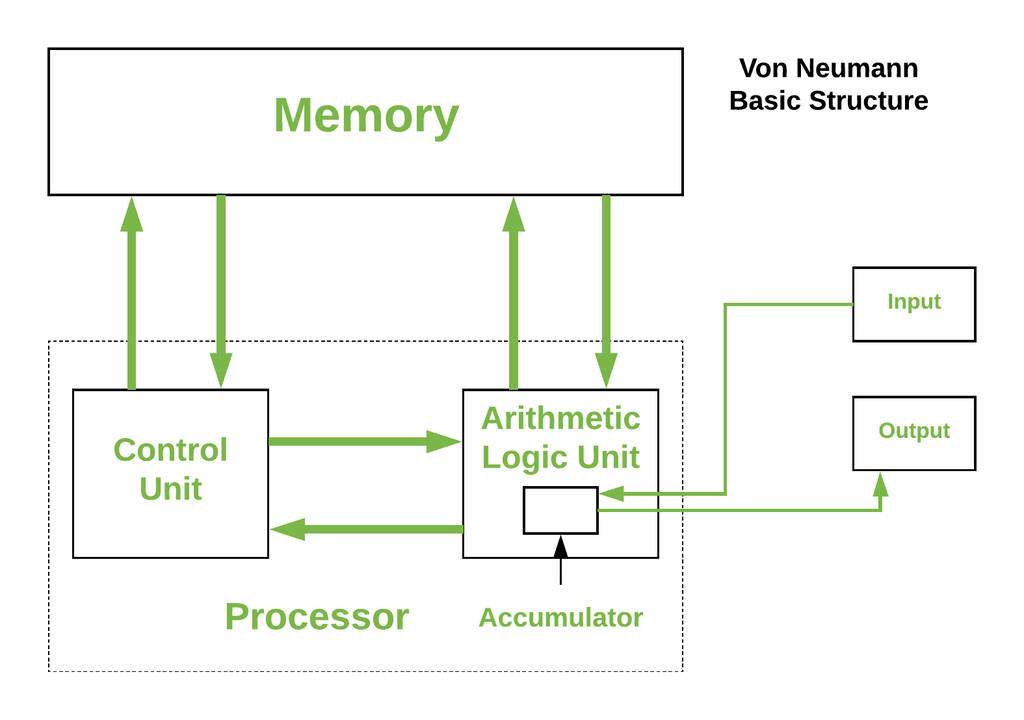

When buying a computer it is also advisable to look at the performance of the CPU and RAM. Higher the clock rate (GHz) and number of cores means the CPU can execute more commands in a given time. Higher RAM size (GB) means the machine spirit can remember more and more data at the same time.  
Maybe it’s not surprising that *statistical computation are more RAM intensive than CPU intensive* since in statistics, we work with loads of data. We need a computer with 16-31 GB of RAM to run more complex statistical models in reasonable time on a real corporate dataset that usually has more than one million records (or observations) and at least 30-40 columns (or variables).

## 3. Interface of R Studio

Once base R and R Studio is installed on our computer, we should launch R Studio.  
After launch, usually a similar picture unfolds before us like the one below here:

[figure not shown]

R codes in R Studio are written in a script file with an extension of *.R*.  
A file like this can be created in the following way:

[video not shown]

In the newly created script, we can type our commands for the machine spirit to execute in the R language. We can order the machine to execute out commands by pressing the **Run** button located in the upper right corner of the script file. The machine spirit tells the result of our command at the bottom of the screen in the *Console* area. By default, the computer always executes the command where we the cursor is blinking in the script when pressing the **Run** button.  
In the following example, we get R to calculate us the result of $3+2$:

[video not shown]

We can execute multiple commands at once. We just need to highlight the commands to execute in the script and then press the **Run** button (after highlighting).  
A command can be broken into multiple lines, but a new command always has to start in a new line! It’s advisable to leave an empty line between commands to better separate the code.

Now, let’s make R calculate the results of two operations: $3+2$ and $3 \times 2$:

[video not shown]

From this point on, I’ll mark the R code snippets and their results in the following way:

```r
3+2
```

```
## [1] 5
```

```r
3*2
```

```
## [1] 6
```

## 4. Working Directory

Before we start exploring the deeper mysteries of R, we should address the question of *Working Directory*.  
The *Working Directory* is the folder where R wants to save all of our script files with *.R* extension. Furthermore, we can load files into R’s memory that are located in this folder by default.  
We can select the folder that serves as *Working Directory* in the pane at the right bottom corner of R Studio.  
Once this folder is set, all of our files will be saved here and we should copy every datasets to this folder that we will want to work with in R.  
To set the *Working Directory*, we should click on the tiny **…** button located in the right bottom corner of R Studio. By clicking on this button, we can select a folder. Once the folder is selected, we should find the **More** button (also in the right bottom corner of R Studio) left click on it, and then select the **Set As Working Directory** option.  
This chain of events generates the following R code (naturally, everyone will have a different folder paths between the quotations):

```r
setwd("~/Github Repok/Statistical-Modelling-Lecture-Notes")
```

This command above should be copied to the start of our R scripts and always run this command once R Studio is launched. This way, R will look for our files in the appropriate folder.  
Of course, you can also set the *Working Directory* by rewriting the command above between the quotations marks and running the new command.

In the right bottom corner of R Studio, we can automatically navigate to the current *Working Directory* by clicking **More –> Go To Working Directory**.

This whole setting the *Working Directory* business can be watched together on the following video:

[video not shown]

If during the saving of our *.R* scripts, the machine spirit asks us which *character encoding* we would like to use, then we should select the **UTF-8** standard since it is the most common character encoding for English language files:

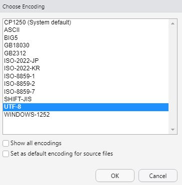

## 5. Data Types and Data Structures in R

So far, we have only executed commands in R, but we haven’t really stored anything in the memory (RAM).  
Now’s the time! Results of commands can be saved to memory and can be given a sympathetic name with the `<-` symbol.

### 5.1. Simple Data Types

Let’s save the result of $3+2$ into an R memory object called `calc_result`: `calc_result <- 3+2`. After executing this command, the `calc_result` object will appear in the *upper right corner* of R Studio. On this side of R Studio, we can always see all the R objects that are currently “alive” inside the RAM:

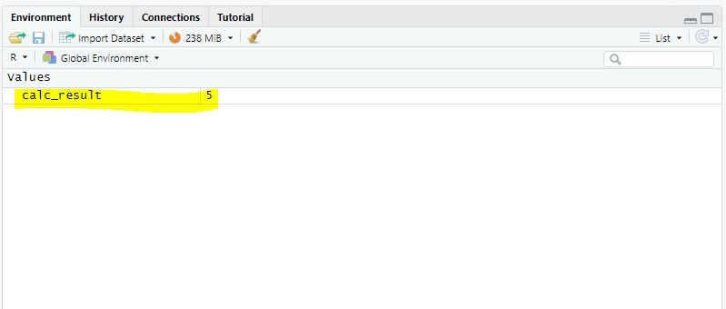

R memory objects have multiple types. The most simple ones only store one value (like `calc_result` from before). These simple objects are sometimes called as *variable*s. I don’t really like this appellation since it can be confused with a variable in a statistical sense. Statistical variables always refer to some property of a statistical observation (e.g. monthly income of an employee).

R objects always have a data type as well. It describes whether the current object contains numerical, textual, date or some other kind of data. This is extremely important since the **data type determines how much space is needed in the RAM to store the object**. I think that it can be sensed immediately that we need more memory space to store a text of arbitrary length than we need to store an arbitrary integer number.

Data types can be queried by the R *functions* `str` and `typeof`.

It should be noted at this point that R has built-in commands that work like mathematical **functions*. So, these R functions are commands that follow the form of a classical $f(x)$ function in mathematics.  
Name of the function gives the name of the operation this function will execute on the computer and inside the brackets we give the input parameters (input data) on which this operation needs to be executed. For example, the `setwd` command is also a function.

So, let’s see in practice, how these R function work through the examples of `str` and `typeof`:

```r
calc_result <- 3+2

str(calc_result)
```

```
##  num 5
```

```r
typeof(calc_result)
```

```
## [1] "double"
```

We can see from the results that `str` only tells us that the object in question is a numerical one, but `typeof` reveals that this object is a `double` type number. The `double` type numbers are numerical data types that can store fractions as well not just integers.

The function `str` also shows the current value stored in the object (which is `5` in the example above) next to its data type.

There exist a data type called `integer` that can only store whole numbers, or in other name integers. To create an object with this data type you need to put the letter `L` next to the number:

```r
whole_number <- 3L

str(whole_number)
```

```
##  int 3
```

```r
typeof(whole_number)
```

```
## [1] "integer"
```

In our course, it won’t have any significance, but if you need to handle true **big data**, then in order to save RAM storage, even the difference between integers and doubles matter! So, you don’t want to use up the space needed for doubles to store something that can only be an integer number!

Some other important data types and their definitons:

```r
textual <- "HelloThere" # Text in code should be put between quotation marks! Like in Excel! :)

str(textual)
```

```
##  chr "HelloThere"
```

```r
typeof(textual)
```

```
## [1] "character"
```

```r
true_or_false <- TRUE

str(true_or_false)
```

```
##  logi TRUE
```

```r
typeof(true_or_false) # a logical data types can store only 2 values: TRUE or FALSE
```

```
## [1] "logical"
```

In the code snippet above, the **#** mark is the mark for comments in R. Things written behind a **#** are not executed by the machine spirit. This way, we can write useful comments and notes for ourselves in the R script.

Like we can convert numbers to texts:

```r
number <- 1992

typeof(number)
```

```
## [1] "double"
```

```r
textual <- as.character(number)

typeof(textual)
```

```
## [1] "character"
```

We can convert text to numeric type if the text truly contains a valid number:

```r
textual <- "1992"

typeof(textual)
```

```
## [1] "character"
```

```r
number <- as.numeric(textual)

typeof(number)
```

```
## [1] "double"
```

Be careful with decimals! **R always assumes decimal points!** So, if you use a decimal comma for example, then the machine spirit becomes angry and throws you a hysterical error message. :( Value of the object called `nogood` will be empty which is `NA` in the language of R:

```r
nogood <- as.numeric("3,14")
nogood
```

```
## [1] NA
```

```r
typeof(nogood)
```

```
## [1] "double"
```

```r
good <- as.numeric("3.14")

good
```

```
## [1] 3.14
```

```r
typeof(good)
```

```
## [1] "double"
```

### 5.2. Data Structures

#### Vectors

We can create R objects containing multiple values with the function `c`. The name of this kind of objects containing multiple values in a sequence is **vector**.

```r
many_numbers <- c(3.14, 2.67, 88, 1234)

str(many_numbers)
```

```
##  num [1:4] 3.14 2.67 88 1234
```

```r
typeof(many_numbers)
```

```
## [1] "double"
```

Let’s discover that `str` and `typeof` functions both tell us that the data type of out new object is numeric. This is because **vector objects can only store values of the same data type**!

If we want to store values of different data types in a vector, then R converts everything to the most general data type. Which is in the example below is `character`:

```r
many_numbers_texts <- c(88, 42, "Hello", 1992, 9, "There", "Friend", 11)

str(many_numbers_texts)
```

```
##  chr [1:8] "88" "42" "Hello" "1992" "9" "There" "Friend" "11"
```

```r
typeof(many_numbers_texts)
```

```
## [1] "character"
```

After all of this, let’s see how can we execute different tasks and operations with vectors!

Lets query the number of elements in a vector:

```r
many_numbers <- c(3.14, 2.67, 88, 1234, 42.5)

length(many_numbers)
```

```
## [1] 5
```

Select the $3$rd element:

```r
many_numbers[3]
```

```
## [1] 88
```

Select every element from 2 to 4:

```r
many_numbers[2:4]
```

```
## [1]    2.67   88.00 1234.00
```

Select the $2$nd and $4$th elements only! Note that the seleted elements are also given as a *vector* here:

```r
many_numbers[c(2,4)]
```

```
## [1]    2.67 1234.00
```

Select all elements but the $3$rd:

```r
many_numbers[-3]
```

```
## [1]    3.14    2.67 1234.00   42.50
```

To annoy the machine spirit, let’s select an element that does not exists:

```r
many_numbers[6]
```

```
## [1] NA
```

This time we get an empty value (`NA`)!

Let’s order the elements of the vector that contains numerical data only:

```r
order(many_numbers)
```

```
## [1] 2 1 5 3 4
```

```r
many_numbers[order(many_numbers)]
```

```
## [1]    2.67    3.14   42.50   88.00 1234.00
```

Let’s order the elements of the same vector but now do it decreasingly:

```r
ordered_numbers <- many_numbers[order(many_numbers, decreasing = TRUE)]
ordered_numbers
```

```
## [1] 1234.00   88.00   42.50    3.14    2.67
```

Note that the `order` function has a second parameter that gives the direction of the ordering. The parameters, or in other words *arguments* of a function can be found in the [online documentation for the R language](https://www.rdocumentation.org/). You should just type in the function that you’re looking for in the search bar.

Elegantly you can say that the documentation gives the *callable parameters* of an R function.

When using the documentation and R in general be careful for the fact that R is a **case-sensitive** language! This means that the difference between small and large letters matter! Like the `order` function is **not** the same as the `Order` function!!

#### Lists

If you want to store objects of different data types in a new object, than you can use `list`s:

```r
many_numbers_texts <- c(88, 42, "Hello", 1992, 9, "There", "Friend", 11)
many_numbers <- c(3.14, 2.67, 88, 1234, 42.5)
yesno <- TRUE
welcome <- "Hi-Hi"


blacklist <- list(many_numbers_texts, many_numbers, yesno, welcome)

str(blacklist) # the function shows elements of the list separated with $ signs
```

```
## List of 4
##  $ : chr [1:8] "88" "42" "Hello" "1992" ...
##  $ : num [1:5] 3.14 2.67 88 1234 42.5
##  $ : logi TRUE
##  $ : chr "Hi-Hi"
```

```r
typeof(blacklist) # this just returns that out object is a list
```

```
## [1] "list"
```

Number of elements in a list can be queried with the `length` function as well.

On the other hand, if you need to select an element from the list, then you’ll need use some tricks since the method applied in the case of vectors does not work here:

```r
blacklist[2]
```

```
## [[1]]
## [1]    3.14    2.67   88.00 1234.00   42.50
```

```r
typeof(blacklist[2])
```

```
## [1] "list"
```

The `blacklist[2]` is still a list, **not a vector of numbers as it should be**!

If you really want to select the `many_numbers` object from the list, you need to do this:

```r
blacklist[[2]]
```

```
## [1]    3.14    2.67   88.00 1234.00   42.50
```

```r
typeof(blacklist[[2]]) # now, we get back a numerical vector as we should
```

```
## [1] "double"
```

If this method seems quite uncomfortable, then we can create the list by naming each element:

```r
many_numbers_texts <- c(88, 42, "Hello", 1992, 9, "There", "Friend", 11)
many_numbers <- c(3.14, 2.67, 88, 1234, 42.5)
yesno <- TRUE
welcome <- "Hi-Hi"


blacklist <- list(first = many_numbers_texts, second = many_numbers,
                    third = yesno, fourth = welcome)

str(blacklist)
```

```
## List of 4
##  $ first : chr [1:8] "88" "42" "Hello" "1992" ...
##  $ second: num [1:5] 3.14 2.67 88 1234 42.5
##  $ third : logi TRUE
##  $ fourth: chr "Hi-Hi"
```

Now, by naming elements in the list, we can refer to elements in a list by using their names rather their number. As the result of the `str` function suggests, you can refer the names by the `$` sign.

Let’s select the $2$nd element of `blacklist` by its name. The name is quite unimaginatively also `second`.

```r
blacklist$second
```

```
## [1]    3.14    2.67   88.00 1234.00   42.50
```

```r
typeof(blacklist$second)
```

```
## [1] "double"
```

As we have expected, the result is a numerical (specifically `double`) vector with $5$ elements.

Before we continue, let’s erase all the R objects we’ve created so far from the RAM. This can be done by forcefully pressing the **broom** button in the upper right corner of R Studio.

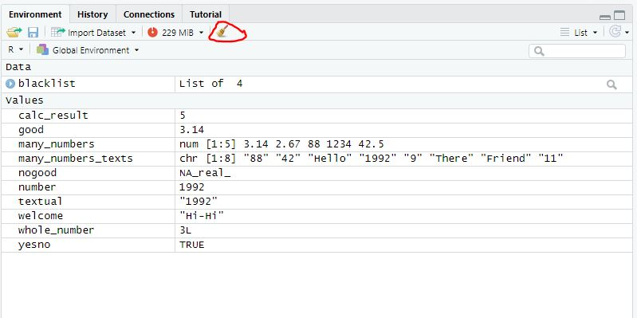

## 6. Handling Datasets in R

The easiest way to load a dataset into R’s memory is to use **files in csv formats** and apply the `read.csv` function. Files with **csv** extensions are essentially **txt** files that contain a table where the columns are separated by **commas**. Hence the name: *comma separated values = csv*

**WARNING!** The `read.csv` expects the following structur from the table stored in the **csv** file:

- columns are separated by commas
- decimal places are marked by points
- textual data is between quotation marks

If we download *csv* datasets from English websites like [Kaggle](https://www.kaggle.com/), then they probably satisfy all three conditions given above, but it’s better to be safe.

R expects the following logical structure from the dataset to be loaded: rows of the table must contain the statistical observations or records (people, countries, houses, cars, etc.) and columns must contain the properties describing the observations (people’s age, GDP of countries, brands of cars, prices of houses, etc.). These properties are called *variables* in statistics.

The COVID_0326.csv file satisfies every technical and logical requirements. It contains $100$ countries as observations and we have $9$ variables descriving these countries:

- Country: name of the country
- Pop: population of the country (people)
- PopDens: population density (people/km2)
- Prop_UrbanPop: proportion of urban population in 2019 (%)
- PressLiberty: press liberty index in 2019 (lower = press is more free)
- PerCapita_HealthExp_2016: per capita health expenditures based on purchasing power parity (2016)
- COVID19_CasesPerMillion: registered COVID-19 infections per million people on 26th March 2020.
- ConstitutionalForm: constitutional form of the country
- HeadOfState: head of state’s rights (has executive powers or just representational)

Let’s read this table to the R memory via the `read.csv` functions. Let’s name the object containing the table as `COVID`:

```r
COVID <- read.csv("COVID_0326.csv")
# this only works if the csv file is in the Working Directory which was set before!!
```

If, we’re all right that we have a table called `COVID` in the memory with $100$ observations and $9$ variables:

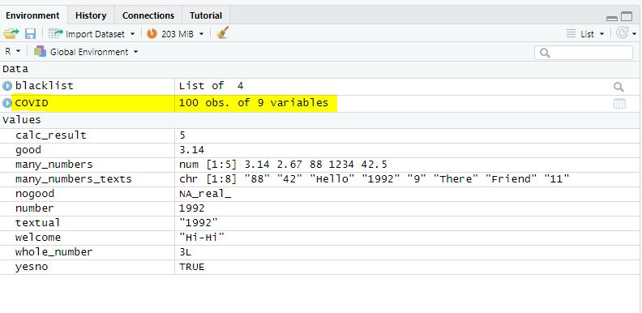

The `read.csv` function can also read *csv* files from website links as well. Like the following code could also work.

```r
COVID <- read.csv("https://raw.githubusercontent.com/KoLa992/Statistical-Modelling-Lecture-Notes/main/COVID_0326.csv")
```

Let’s see what is the structure and type of this `COVID` object in the RAM:

```r
typeof(COVID)
```

```
## [1] "list"
```

```r
str(COVID)
```

```
## 'data.frame':    100 obs. of  9 variables:
##  $ Country                 : chr  "Afghanistan" "Albania" "Algeria" "Argentina" ...
##  $ Pop                     : int  38928346 2877797 43851044 45195774 2963243 25499884 10139177 9449323 11589623 397628 ...
##  $ PopDens                 : int  60 105 18 17 104 3 123 47 383 17 ...
##  $ Prop_UrbanPop           : int  25 63 73 93 63 86 56 79 98 46 ...
##  $ PressLiberty            : num  27.7 29.8 45.8 28.3 28.7 ...
##  $ PerCapita_HealthExp_2016: num  163 760 998 1531 877 ...
##  $ COVID19_CasesPerMillion : num  2.41 60.46 8.37 11.11 97.87 ...
##  $ ConstitutionalForm      : chr  "Republic" "Republic" "Republic" "Republic" ...
##  $ HeadOfState             : chr  "Executive" "Ceremonial" "Executive" "Executive" ...
```

Well, according to `typeof`, we have a `list`, but `str` says its a `data frame`. Altohough, the `$` signs in the result of the `str` do suggest that what we see here is a `list`.

The answer is that R stores datasets in a special object type called data frame, which is actually **a list of vectors with the same length**! So, an element of the list is actually a column (variable) of the data table. This is what we can see from the names after the `$` signs in the result of `str`.

So, you can select a column of the data frame via the `$` sign like in a list:

```r
COVID$COVID19_CasesPerMillion
```

```
##   [1]   2.414693  60.462917   8.369242  11.107233  97.865750 110.196580
##   [7]  12.032535   9.101181 537.981261   5.029827   2.591990   3.683708
##  [13]  58.217171  14.043132  37.994112   7.271589   5.741982   2.825299
##  [19] 107.121602  68.319014  56.823907   9.649609  45.346417 120.576810
##  [25]   5.915271 120.925094 349.262681  11.133603  44.985624  79.521380
##  [31]   4.837083   2.004254   8.553192 405.567889   5.577587 172.901717
##  [37] 452.725762   3.145030  19.803633 524.420300   4.248069  85.579524
##  [43]   6.356859   5.250082  27.017652   3.264800   9.497174 368.383725
##  [49] 311.130392   8.780322  10.966468  20.777930   5.911580   6.744127
##  [55] 129.360756  53.915899 109.834040  62.751037  24.049846 303.481201
##  [61]  63.690862   3.684091  43.877448   3.355408 109.861066   7.450442
##  [67]   3.148484 435.836346  58.686505  21.344818   5.437038 129.323321
##  [73]   5.748304  17.590761   6.451844  32.261805 347.563121 190.555328
##  [79]  53.488748   3.860343  29.068873   6.270930  43.949147  71.176548
##  [85]  41.394656 270.330332  15.630087   4.950206  13.637169 281.208583
##  [91]  14.971351   2.778206  46.445557  16.668614  43.028695   4.481663
##  [97]  33.669006 173.997556  62.468874   2.240866
```

```r
str(COVID$COVID19_CasesPerMillion)
```

```
##  num [1:100] 2.41 60.46 8.37 11.11 97.87 ...
```

### 6.1. Basic Operations in Data Frames

Let’s see the basic operations in a `data frame` object!

We can look into the first few rows with the `head` function (by default the first 6):

```r
head(COVID) # shows first 6 rows by default
```

|  | Country | Pop | PopDens | Prop_UrbanPop | PressLiberty | PerCapita_HealthExp_2016 | COVID19_CasesPerMillion | ConstitutionalForm | HeadOfState |
| --- | --- | --- | --- | --- | --- | --- | --- | --- | --- |
| 1 | Afghanistan | 38928346 | 60 | 25 | 27.66757 | 162.8 | 2.414693 | Republic | Executive |
| 2 | Albania | 2877797 | 105 | 63 | 29.83647 | 759.7 | 60.462917 | Republic | Ceremonial |
| 3 | Algeria | 43851044 | 18 | 73 | 45.75159 | 998.2 | 8.369242 | Republic | Executive |
| 4 | Argentina | 45195774 | 17 | 93 | 28.30321 | 1531.0 | 11.107233 | Republic | Executive |
| 5 | Armenia | 2963243 | 104 | 63 | 28.74149 | 876.9 | 97.865750 | Republic | Ceremonial |
| 6 | Australia | 25499884 | 3 | 86 | 16.54625 | 4529.9 | 110.196580 | Constitutional monarchy | Ceremonial |

```r
head(COVID, n=3) # now we can only see the first 3 rows
```

|  | Country | Pop | PopDens | Prop_UrbanPop | PressLiberty | PerCapita_HealthExp_2016 | COVID19_CasesPerMillion | ConstitutionalForm | HeadOfState |
| --- | --- | --- | --- | --- | --- | --- | --- | --- | --- |
| 1 | Afghanistan | 38928346 | 60 | 25 | 27.66757 | 162.8 | 2.414693 | Republic | Executive |
| 2 | Albania | 2877797 | 105 | 63 | 29.83647 | 759.7 | 60.462917 | Republic | Ceremonial |
| 3 | Algeria | 43851044 | 18 | 73 | 45.75159 | 998.2 | 8.369242 | Republic | Executive |

We can query the number of rows (observations) and the number of columns (variables):

```r
ncol(COVID)
```

```
## [1] 9
```

```r
nrow(COVID)
```

```
## [1] 100
```

We can rename columns by using the `colnames` function that extracts the column names to a vector:

```r
colnames(COVID) # look at the column names
```

```
## [1] "Country"                  "Pop"
## [3] "PopDens"                  "Prop_UrbanPop"
## [5] "PressLiberty"             "PerCapita_HealthExp_2016"
## [7] "COVID19_CasesPerMillion"  "ConstitutionalForm"
## [9] "HeadOfState"
```

```r
# rename the Country column (that is the 1st column) to CountryName
colnames(COVID)[1] <- "CountryName"

# look at the results
colnames(COVID)
```

```
## [1] "CountryName"              "Pop"
## [3] "PopDens"                  "Prop_UrbanPop"
## [5] "PressLiberty"             "PerCapita_HealthExp_2016"
## [7] "COVID19_CasesPerMillion"  "ConstitutionalForm"
## [9] "HeadOfState"
```

We can calculate new columns to our table from existing columns. For example, let’s calculate the area of each country in acres (1 km2 = 100 ac)

```r
COVID$Area <- (COVID$Pop / COVID$PopDens) * 100 # remember: population density is in people/km2!

head(COVID$Area)
```

```
## [1]  64880577   2740759 243616911 265857494   2849272 849996133
```

These tricks can be played on every *vector*: they can be mathematically transformed by normal mathematical operators and by R functions.

Let’s define two numerical vectors:

```r
this <- c(1,2,3,4)

that <- c(6,7,8,9)
```

We can add and multiply the corresponding elements of the two vectors:

```r
this + that
```

```
## [1]  7  9 11 13
```

```r
this * that
```

```
## [1]  6 14 24 36
```

Get the squared elements of `that`:

```r
that^2
```

```
## [1] 36 49 64 81
```

We can calculate the sumproduct of the two vectors by applying multiplication sign (`*`) and the `sum` function:

```r
sum(this * that)
```

```
## [1] 80
```

We can also get the mean of the elements in `this` by applying the `mean` function on it:

```r
mean(this)
```

```
## [1] 2.5
```

### 6.2. Selecting Rows and Column in a Dataframe

Naturally, in a data table, the most basic operation is selecting specific rows and columns.

We can select the 42nd row and 7th column in many different ways.

```r
COVID[42,7] # this is a bit of matrix operation logic: [row,column] references
```

```
## [1] 85.57952
```

```r
COVID[42,"COVID19_CasesPerMillion"] # the column can also be referenced by its name instead of its number
```

```
## [1] 85.57952
```

```r
COVID$COVID19_CasesPerMillion[42] # here I’m specifically saying that we extract the column (or list element) named COVID19_CasesPerMillion from the list using the $ symbol and check its 42nd element
```

```
## [1] 85.57952
```

We can select the entire 42nd row.

```r
COVID[42,] # in this case, we simply leave the column reference empty, but we still write the comma!
```

|  | CountryName | Pop | PopDens | Prop_UrbanPop | PressLiberty | PerCapita_HealthExp_2016 | COVID19_CasesPerMillion | ConstitutionalForm | HeadOfState | Area |
| --- | --- | --- | --- | --- | --- | --- | --- | --- | --- | --- |
| 42 | Greece | 10423054 | 81 | 85 | 29.08402 | 2261.2 | 85.57952 | Republic | Ceremonial | 12867968 |

Or the entire 7th column.

```r
COVID[,7] # in this case, we simply leave the row reference empty, but we still write the comma!
```

```
##   [1]   2.414693  60.462917   8.369242  11.107233  97.865750 110.196580
##   [7]  12.032535   9.101181 537.981261   5.029827   2.591990   3.683708
##  [13]  58.217171  14.043132  37.994112   7.271589   5.741982   2.825299
##  [19] 107.121602  68.319014  56.823907   9.649609  45.346417 120.576810
##  [25]   5.915271 120.925094 349.262681  11.133603  44.985624  79.521380
##  [31]   4.837083   2.004254   8.553192 405.567889   5.577587 172.901717
##  [37] 452.725762   3.145030  19.803633 524.420300   4.248069  85.579524
##  [43]   6.356859   5.250082  27.017652   3.264800   9.497174 368.383725
##  [49] 311.130392   8.780322  10.966468  20.777930   5.911580   6.744127
##  [55] 129.360756  53.915899 109.834040  62.751037  24.049846 303.481201
##  [61]  63.690862   3.684091  43.877448   3.355408 109.861066   7.450442
##  [67]   3.148484 435.836346  58.686505  21.344818   5.437038 129.323321
##  [73]   5.748304  17.590761   6.451844  32.261805 347.563121 190.555328
##  [79]  53.488748   3.860343  29.068873   6.270930  43.949147  71.176548
##  [85]  41.394656 270.330332  15.630087   4.950206  13.637169 281.208583
##  [91]  14.971351   2.778206  46.445557  16.668614  43.028695   4.481663
##  [97]  33.669006 173.997556  62.468874   2.240866
```

```r
COVID[,"COVID19_CasesPerMillion"]
```

```
##   [1]   2.414693  60.462917   8.369242  11.107233  97.865750 110.196580
##   [7]  12.032535   9.101181 537.981261   5.029827   2.591990   3.683708
##  [13]  58.217171  14.043132  37.994112   7.271589   5.741982   2.825299
##  [19] 107.121602  68.319014  56.823907   9.649609  45.346417 120.576810
##  [25]   5.915271 120.925094 349.262681  11.133603  44.985624  79.521380
##  [31]   4.837083   2.004254   8.553192 405.567889   5.577587 172.901717
##  [37] 452.725762   3.145030  19.803633 524.420300   4.248069  85.579524
##  [43]   6.356859   5.250082  27.017652   3.264800   9.497174 368.383725
##  [49] 311.130392   8.780322  10.966468  20.777930   5.911580   6.744127
##  [55] 129.360756  53.915899 109.834040  62.751037  24.049846 303.481201
##  [61]  63.690862   3.684091  43.877448   3.355408 109.861066   7.450442
##  [67]   3.148484 435.836346  58.686505  21.344818   5.437038 129.323321
##  [73]   5.748304  17.590761   6.451844  32.261805 347.563121 190.555328
##  [79]  53.488748   3.860343  29.068873   6.270930  43.949147  71.176548
##  [85]  41.394656 270.330332  15.630087   4.950206  13.637169 281.208583
##  [91]  14.971351   2.778206  46.445557  16.668614  43.028695   4.481663
##  [97]  33.669006 173.997556  62.468874   2.240866
```

```r
COVID$COVID19_CasesPerMillion
```

```
##   [1]   2.414693  60.462917   8.369242  11.107233  97.865750 110.196580
##   [7]  12.032535   9.101181 537.981261   5.029827   2.591990   3.683708
##  [13]  58.217171  14.043132  37.994112   7.271589   5.741982   2.825299
##  [19] 107.121602  68.319014  56.823907   9.649609  45.346417 120.576810
##  [25]   5.915271 120.925094 349.262681  11.133603  44.985624  79.521380
##  [31]   4.837083   2.004254   8.553192 405.567889   5.577587 172.901717
##  [37] 452.725762   3.145030  19.803633 524.420300   4.248069  85.579524
##  [43]   6.356859   5.250082  27.017652   3.264800   9.497174 368.383725
##  [49] 311.130392   8.780322  10.966468  20.777930   5.911580   6.744127
##  [55] 129.360756  53.915899 109.834040  62.751037  24.049846 303.481201
##  [61]  63.690862   3.684091  43.877448   3.355408 109.861066   7.450442
##  [67]   3.148484 435.836346  58.686505  21.344818   5.437038 129.323321
##  [73]   5.748304  17.590761   6.451844  32.261805 347.563121 190.555328
##  [79]  53.488748   3.860343  29.068873   6.270930  43.949147  71.176548
##  [85]  41.394656 270.330332  15.630087   4.950206  13.637169 281.208583
##  [91]  14.971351   2.778206  46.445557  16.668614  43.028695   4.481663
##  [97]  33.669006 173.997556  62.468874   2.240866
```

We can also select multiple rows and columns if we place vectors in the references between the `[]` signs.

```r
COVID[c(1,50,60,80),c(1,4,7)]
```

|  | CountryName | Prop_UrbanPop | COVID19_CasesPerMillion |
| --- | --- | --- | --- |
| 1 | Afghanistan | 25 | 2.414693 |
| 50 | Jamaica | 55 | 8.780322 |
| 60 | Malta | 93 | 303.481201 |
| 80 | Rwanda | 18 | 3.860343 |

```r
COVID[c(1,50,60,80),c("CountryName","Prop_UrbanPop","COVID19_CasesPerMillion")]
```

|  | CountryName | Prop_UrbanPop | COVID19_CasesPerMillion |
| --- | --- | --- | --- |
| 1 | Afghanistan | 25 | 2.414693 |
| 50 | Jamaica | 55 | 8.780322 |
| 60 | Malta | 93 | 303.481201 |
| 80 | Rwanda | 18 | 3.860343 |

```r
COVID[20:30,c("CountryName","Prop_UrbanPop","COVID19_CasesPerMillion")] # if the rows to be selected are consecutive, it can be done like this
```

|  | CountryName | Prop_UrbanPop | COVID19_CasesPerMillion |
| --- | --- | --- | --- |
| 20 | Chile | 85 | 68.319014 |
| 21 | China | 61 | 56.823907 |
| 22 | Colombia | 80 | 9.649609 |
| 23 | Costa Rica | 80 | 45.346417 |
| 24 | Croatia | 58 | 120.576810 |
| 25 | Cuba | 78 | 5.915271 |
| 26 | Cyprus | 67 | 120.925094 |
| 27 | Denmark | 88 | 349.262681 |
| 28 | Djibouti | 79 | 11.133603 |
| 29 | Dominican Republic | 85 | 44.985624 |

[output cut: 1 more lines]

```r
COVID[20:30,1:4] # if the columns to be selected are consecutive, it can be done like this
```

|  | CountryName | Pop | PopDens | Prop_UrbanPop |
| --- | --- | --- | --- | --- |
| 20 | Chile | 19116201 | 26 | 85 |
| 21 | China | 1439323776 | 153 | 61 |
| 22 | Colombia | 50882891 | 46 | 80 |
| 23 | Costa Rica | 5094118 | 100 | 80 |
| 24 | Croatia | 4105267 | 73 | 58 |
| 25 | Cuba | 11326616 | 106 | 78 |
| 26 | Cyprus | 1207359 | 131 | 67 |
| 27 | Denmark | 5792202 | 137 | 88 |
| 28 | Djibouti | 988000 | 43 | 79 |
| 29 | Dominican Republic | 10847910 | 225 | 85 |

[output cut: 1 more lines]

The most beautiful thing about all this is that **we can also designate the rows to be selected using logical conditions**. In other words, we can **filter** the data table!

### 6.3. Examples for Logical Filtering in Dataframes

Provide the names of those countries where the COVID case count per million exceeded 100 on 26/03/2020!

```r
COVID[COVID$COVID19_CasesPerMillion > 100, c("CountryName", "COVID19_CasesPerMillion")]
```

|  | CountryName | COVID19_CasesPerMillion |
| --- | --- | --- |
| 6 | Australia | 110.1966 |
| 9 | Belgium | 537.9813 |
| 19 | Canada | 107.1216 |
| 24 | Croatia | 120.5768 |
| 26 | Cyprus | 120.9251 |
| 27 | Denmark | 349.2627 |
| 34 | Estonia | 405.5679 |
| 36 | Finland | 172.9017 |
| 37 | France | 452.7258 |
| 40 | Germany | 524.4203 |

[output cut: 13 more lines]

Provide the names of those countries where the COVID case count per million exceeded 100 on 26/03/2020, **and** the proportion of the urban population is at most 60%!

```r
COVID[COVID$COVID19_CasesPerMillion > 100 & COVID$Prop_UrbanPop <= 60,
      c("CountryName", "Prop_UrbanPop", "COVID19_CasesPerMillion")]
```

|  | CountryName | Prop_UrbanPop | COVID19_CasesPerMillion |
| --- | --- | --- | --- |
| 24 | Croatia | 58 | 120.5768 |
| 86 | Slovenia | 55 | 270.3303 |

Provide the names of those countries where the form of government is an absolute monarchy, **or** the proportion of the urban population is below 35%!

```r
# first, we check what possible values the ConstitutionalForm variable has using the unique function
unique(COVID$ConstitutionalForm)
```

```
## [1] "Republic"                "Constitutional monarchy"
## [3] "Absolute monarchy"
```

```r
# from the result of the unique function, we see that absolute monarchies are listed as "Absolute monarchy" in the table
COVID[COVID$ConstitutionalForm == "Absolute monarchy" | COVID$Prop_UrbanPop < 35,
      c("CountryName", "Prop_UrbanPop", "ConstitutionalForm")]
```

|  | CountryName | Prop_UrbanPop | ConstitutionalForm |
| --- | --- | --- | --- |
| 1 | Afghanistan | 25 | Republic |
| 16 | Burkina Faso | 31 | Republic |
| 17 | Cambodia | 24 | Constitutional monarchy |
| 43 | Guyana | 27 | Republic |
| 70 | Oman | 87 | Absolute monarchy |
| 78 | Qatar | 96 | Absolute monarchy |
| 80 | Rwanda | 18 | Republic |
| 81 | Saudi Arabia | 84 | Absolute monarchy |
| 88 | Sri Lanka | 18 | Republic |

Provide the population density and COVID case counts on 2020.03.26 for Belgium, Hungary, and Croatia!

```r
COVID[COVID$Country %in% c("Belgium", "Hungary", "Croatia"),
      c("CountryName", "PopDens", "COVID19_CasesPerMillion")]
```

|  | CountryName | PopDens | COVID19_CasesPerMillion |
| --- | --- | --- | --- |
| 9 | Belgium | 383 | 537.98126 |
| 24 | Croatia | 73 | 120.57681 |
| 45 | Hungary | 107 | 27.01765 |

Provide the names, forms of government, and COVID case counts on 2020.03.26 for countries that are **not** republics! Save the result in a new data frame called `NonRep`, and display only the first 6 rows of the result!

```r
NonRep <- COVID[COVID$ConstitutionalForm != "Republic",
      c("CountryName", "ConstitutionalForm", "COVID19_CasesPerMillion")]
# note that "!=" is the "not equal" symbol

head(NonRep)
```

|  | CountryName | ConstitutionalForm | COVID19_CasesPerMillion |
| --- | --- | --- | --- |
| 6 | Australia | Constitutional monarchy | 110.196580 |
| 9 | Belgium | Constitutional monarchy | 537.981261 |
| 10 | Belize | Constitutional monarchy | 5.029827 |
| 11 | Bhutan | Constitutional monarchy | 2.591990 |
| 17 | Cambodia | Constitutional monarchy | 5.741982 |
| 19 | Canada | Constitutional monarchy | 107.121602 |

Provide the names of those countries whose form of government is **not** a republic and **not** an absolute monarchy!

```r
COVID[!(COVID$ConstitutionalForm %in% c("Absolute monarchy", "Republic")),
      c("CountryName", "ConstitutionalForm")]
```

|  | CountryName | ConstitutionalForm |
| --- | --- | --- |
| 6 | Australia | Constitutional monarchy |
| 9 | Belgium | Constitutional monarchy |
| 10 | Belize | Constitutional monarchy |
| 11 | Bhutan | Constitutional monarchy |
| 17 | Cambodia | Constitutional monarchy |
| 19 | Canada | Constitutional monarchy |
| 27 | Denmark | Constitutional monarchy |
| 50 | Jamaica | Constitutional monarchy |
| 51 | Japan | Constitutional monarchy |
| 52 | Jordan | Constitutional monarchy |

[output cut: 8 more lines]

```r
# note that "!" is generally the "negation" symbol
```

Of course, if we use the `unique` function, we quickly realize that these are simply the constitutional monarchies, but I wanted to show the *negation* symbol (or operator, to use a nice term). :)

```r
unique(COVID$ConstitutionalForm)
```

```
## [1] "Republic"                "Constitutional monarchy"
## [3] "Absolute monarchy"
```

```r
TargetForm <- unique(COVID$ConstitutionalForm)[2]

COVID[COVID$ConstitutionalForm == TargetForm,
      c("CountryName", "ConstitutionalForm")] # just to show: this works too :)
```

|  | CountryName | ConstitutionalForm |
| --- | --- | --- |
| 6 | Australia | Constitutional monarchy |
| 9 | Belgium | Constitutional monarchy |
| 10 | Belize | Constitutional monarchy |
| 11 | Bhutan | Constitutional monarchy |
| 17 | Cambodia | Constitutional monarchy |
| 19 | Canada | Constitutional monarchy |
| 27 | Denmark | Constitutional monarchy |
| 50 | Jamaica | Constitutional monarchy |
| 51 | Japan | Constitutional monarchy |
| 52 | Jordan | Constitutional monarchy |

[output cut: 8 more lines]

Hopefully, based on the above filtering examples in R code, it’s already clear what kinds of codes can be used to designate logical operations in R instructions:

| Code | Meaning |
| --- | --- |
| < | Lesser |
| > | Greater |
| == | Equal |
| != | Not Equal |
| <= | At Most |
| >= | At Least |
| & | AND |
| \| | OR |
| %in% | INCLUDES |
| ! | NEGATION |

## 7. Installing and Importing External Packages

As I wrote in the introduction, one of the most attractive features of R is that its functionality can be extended by using external libraries called *packages*. These packages add extra functions to the command set of R that are not included in the ‘base’ version.

During the course, we’ll use the following packages rather frequently:

- readr
- psych
- ggplot2
- readxl

Let’s install these! If you get a pop-up window where you need to choose a country, then bravely click *Hungary*! :) If for some reason the machine spirit has a problem with that, then *Austria* is a good alternative.

```r
install.packages("readr")
install.packages("psych")
install.packages("ggplot2")
install.packages("readxl")
```

If during package install, R writes WARNINGs on the console with red colour, then these messages can be ignored. Th red can be terrifying, but until the message in red doesn’t start with *Error*, we’re fine! :)

In order to use functions from the installed packages, they need to be referenced by the `library` function. **This step needs to be done every time you launch R!** Let’s include the package `psych` with this `library` function:

```r
library(psych)
```

Any red messages can be ignored again, if they don’t start with *Error*. :)

Packages can also be installed with the buttons located in the down right corner of R Studio [sorry, i’m a bit clumsy in the video when typing in *psych* :)]:

[video not shown]

## 8. Writing Your Own Functions in R

Often it can make our lives easier if we write a custom R function for frequently repeated instruction sequences, so we don’t always have to copy the same 4-5 lines over and over again, but simply use the function!

```r
avg <- function(x, y){
  our_result <- (x + y)/2
  return(our_result)
}
```

If we run the above code, we see that in the top right part of R Studio, the function named `avg` appears under the **Functions** section.

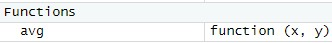

After this, we can simply use it.

```r
testresult <- avg(3, 5)

testresult
```

```
## [1] 4
```

Cool, it calculated that the average of 3 and 5 is 4. :)

We can also write the function so that it only has a single input parameter called $x$, which we assume is of type `vector`, and during averaging, we refer to the 1st and 2nd elements of $x$ using the `[]` symbols.

```r
avg <- function(x){
  our_result <- (x[1] + x[2])/2
  return(our_result)
}
```

Let’s try the function.

```r
input_data <- c(3, 5)

testresult <- avg(input_data)

testresult
```

```
## [1] 4
```

It’s 4 again — amazinggg! :)